# Image3C_ProcessFCS

# Process FCS files

This script and process removes highly correlated features, removes outlier samples, transforms fluorescent intensity parameters, and normalizes and aligns DNA intensity data

```r
#defining some functions required

#scale & center matrices of exprs in each flow frame in the set
scaleSet <- function(fs){
  fsApply(fs, FUN = function(fr){
    mat <- exprs(fr)
    mat <- scale(mat) #scale draq5 intensity parm
    exprs(fr) <- mat
    exprs(fr)

    fr
  })
}

#scale & center DNA intensity parm
#takes flowset and channel number
scaleDNA <- function(fs, ch){
  fsApply(fs, FUN = function(fr, y){
    mat <- exprs(fr)
    mat[,ch] <- scale(mat[,ch]) #scale draq5 intensity parm
    exprs(fr) <- mat
    exprs(fr)

    return(fr)
  })
}

#function to return list of feature means for each sample in a flowset
extractMeans <- function(fs){

  fsApply(fs, FUN = function(fr){
    myrownames <- colnames(fs[[1]])

    frname <- fr@description$GUID
    frname <- strsplit(frname, "\\.") #string split on "."
    frname <- frname[[1]][[1]] #get out 1st element from strsplit output
    mat1 <- exprs(fr)
    means <- colMeans(mat1)
    output1 <- data.frame(cbind(frname, means))
    output1$feature <- rownames(output1)
    rownames(output1) <- seq(length=nrow(output1))
    colnames(output1) <- c("Sample","Means","Feature")
    return(output1)
  })
}


#function from DaMiRseq package to remove features with high correlation to one another
DaMiR.FReduct <- function(data,
                          th.corr=0.85,
                          type=c("spearman","pearson")){

  # check arguments
  if (missing(data)) stop("'data' argument must be provided")
  if (missing(type)){
    type <- type[1]
  }

  # check the type of argument
  if(!(is.numeric(th.corr)))
    stop("'th.corr' must be numeric")
  if(!(is.data.frame(data)))
    stop("'data' must be a data.frame")

  # check the presence of NA or Inf
  if (any(is.na(data)))
    stop("NA values are not allowed in the 'data' matrix")
  if (any(is.infinite(as.matrix(data))))
    stop("Inf values are not allowed in the 'data' matrix")

  # specific checks
  if (th.corr >1 | th.corr < 0)
    stop("'th.corr must be between 0 and 1")
  if (all((as.matrix(data) %%1) == 0))
    warning("It seems that you are using raw counts!
            This function works with normalized data")

  features<-dim(data)[2]

  # remove redundancy
  if(type == "spearman"){
    cormatrix <- abs(rcorr(as.matrix(data), type='spearman')$r)
  } else if (type == "pearson"){
    cormatrix <- abs(rcorr(as.matrix(data), type='pearson')$r)
  } else {
    stop("Please set 'spearman or 'pearson' as correlation type.")
  }

  index_geneHighCorr<- findCorrelation(cormatrix, cutoff = th.corr)
  data_reduced<-data[, -index_geneHighCorr, drop=FALSE]

  cat(features-dim(data_reduced)[2],
      "Highly correlated features have been discarded for classification.",
      "\n",
      dim(data_reduced)[2],
      "Features remained.",
      "\n")
  return(data_reduced)
}

#drop specified colnames
dropSet <- function(fs, toremove){
  fsApply(fs, FUN = function(fr){
    exprs(fr) <- exprs(fr)[,-which(colnames(exprs(fr)) %in% toremove)]
    fr
  })
}
```

## Process FCS files obtained from IDEAS

Let’s load all the packages that we need:

```r
library(flowCore)
library(flowStats)
library(ggcyto)
library(ggridges)
library(stringr)
library(Hmisc)
library(caret)
library(pheatmap)
library(reshape2)
library(data.table)
library(RColorBrewer)
library(knitr)
library(png)
```

```r
#set your working directory containing a copy of  all .fcs files
#setwd("your folder path here")
setwd("~/R_projects/Image3C Markdown/Process FCS")

#read all fcs files in current dir to flowset
myflowset <- read.flowSet(pattern = ".fcs", path = ".", alter.names = TRUE, transformation = FALSE, emptyValue = FALSE)
#get all channel names
mycolnames <- as.character(colnames(exprs(myflowset[[1]])))
#plot histograms for all parameters from a sample file
#autoplot(myflowset[[1]])
```

Next we generate clustering heatmap of feature correlation from a frame in the set. For this step a fully stained and representative sample should be used (not a single color control)

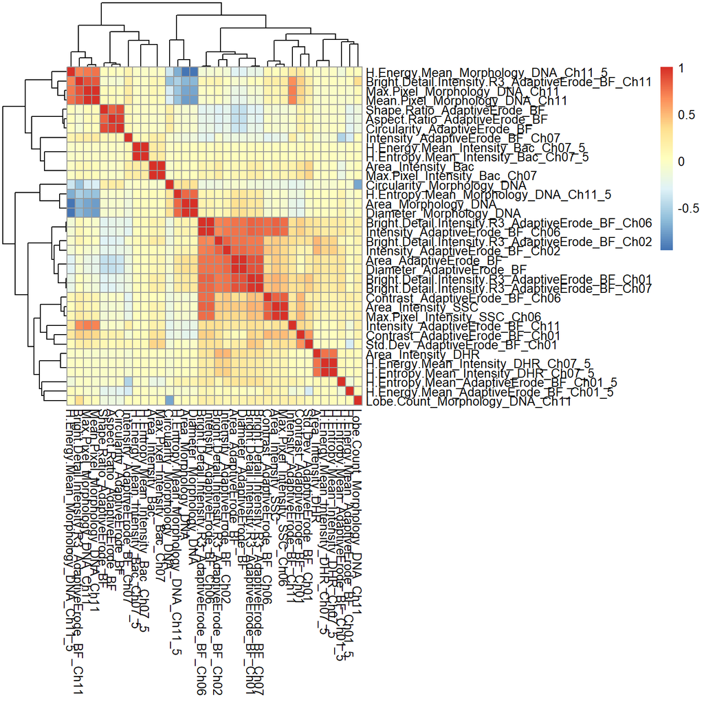

```r
#pull out a single flow frame
myframe <- myflowset[[1]]
#extract matrix
mat <- exprs(myframe)
#get correlation matrix
cor_mat <- cor(mat, method = "spearman")
#plot it using clustering heatmaps
pheatmap(cor_mat)
```

## Remove redundant features based on correlation

```r
#convert data from first sample to data frame object
myfrm <- data.frame(exprs(myframe))
#removes features with Cor values > 0.85
frmTrim <- DaMiR.FReduct(myfrm, th.corr = 0.85)
```

```
## 13 Highly correlated features have been discarded for classification.
##  23 Features remained.
```

```r
#get names of remaining features
colstrimmed <- colnames(frmTrim)
#set operation to find difference with total
toremove <- setdiff(mycolnames, colstrimmed)

myflowset <- dropSet(myflowset, toremove)
```

Now we generate new clustering heatmap again to check how it looks after removal

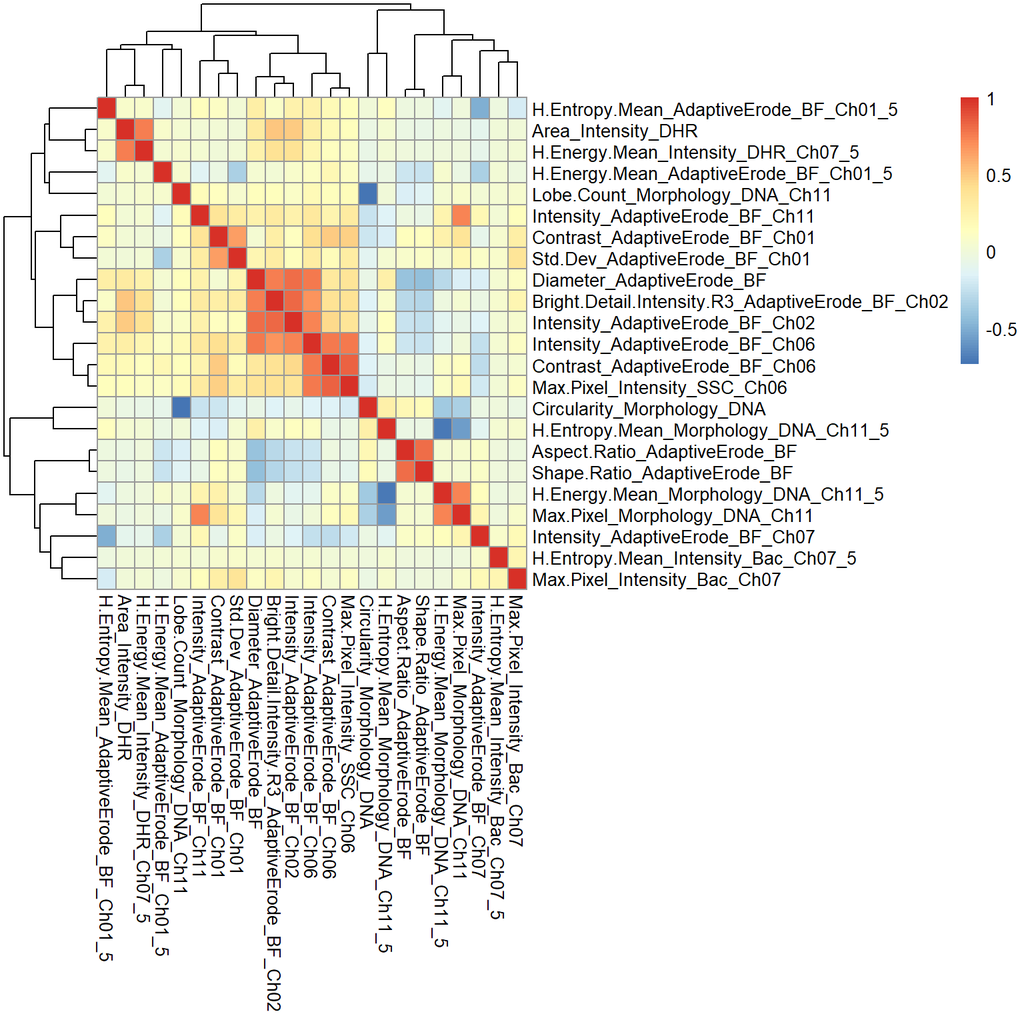

```r
#pull out a single flow frame
myframe <- myflowset[[1]]
#extract matrix
mat <- exprs(myframe)
#get correlation matrix
cor_mat <- cor(mat, method = "spearman")
#plot it using clustering heatmaps
pheatmap(cor_mat)
```

Now calculate sample correlations by feature means

```r
#get a list of features means, one list item per file
myMeans <- extractMeans(myflowset)
#combine to one big table
myMeans <- rbindlist(myMeans)
#recast to wide form
myMeans <- dcast(myMeans, Sample ~ Feature, value.var = "Means")
#rename rownames
rownames(myMeans) <- myMeans$Sample
#remove redundant col
myMeans[,1] <- NULL
#convert all to numeric
myMeans[] <- lapply(myMeans, function(x) {
  as.numeric(as.character(x))
})

#convert to matrix
meansMat <- as.matrix(myMeans)
rownames(meansMat) <- rownames(myMeans)
#convert to matrix
meansMat[!is.finite(meansMat)]
```

```
## numeric(0)
```

```r
#save table, will manipulate to produce an annotation dataframe, see below
write.csv(rownames(meansMat), file="NamesToGroup.csv")
```

### **Manual step - edit “NamesToGroup.csv” to match this format**

Use excel or your favorite spreadsheet application to alter the structure of NamesToGroup.csv as shown below and save the file as “RowLabels.csv”.

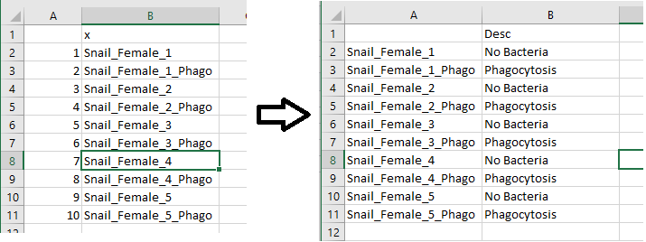

```r
rowAnnot <- read.csv(file="RowLabels.csv")
#put rownames from means table
rownames(rowAnnot) <- rownames(meansMat)
#remove redundant column
rowAnnot[,1] <- NULL
#check that sample names match, should return NULL
setdiff(myflowset@phenoData@data$names,rowAnnot$X)
```

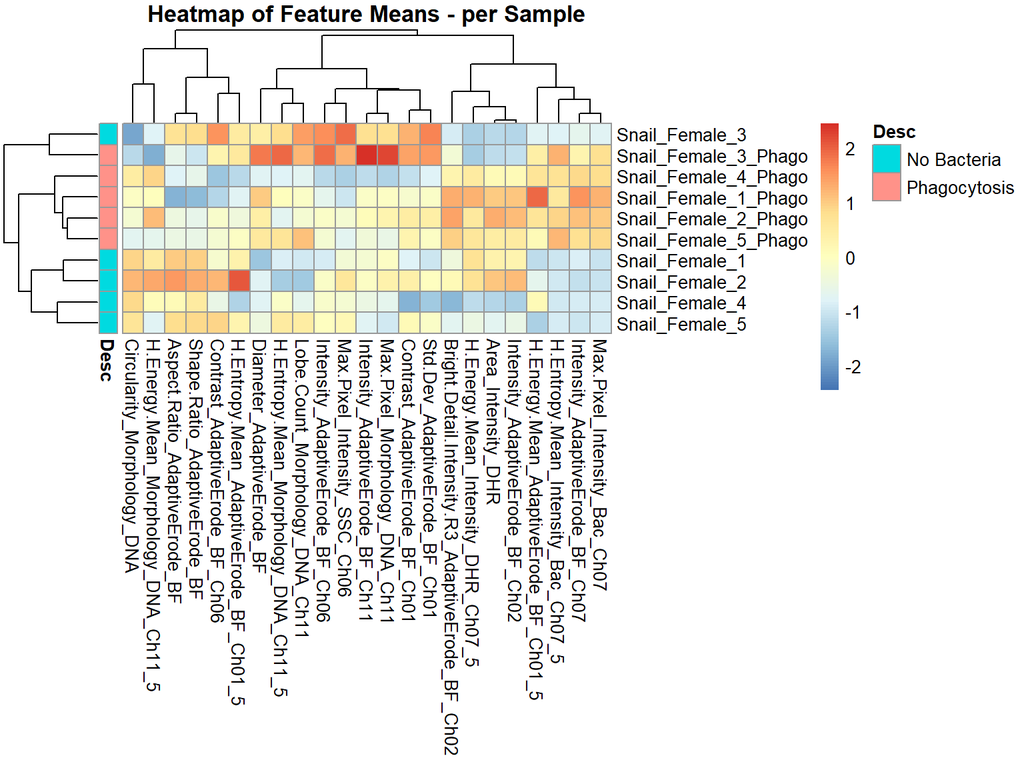

```r
rowAnnotBak <- rowAnnot
#make clustering heatmap of feature means per sample
pheatmap(meansMat, scale = "column", annotation_row = rowAnnot, main = "Heatmap of Feature Means - per Sample")
```

## Plot heatmap of correlation among samples, by feature means

make correlation heatmap with color range for 0.9 to 1

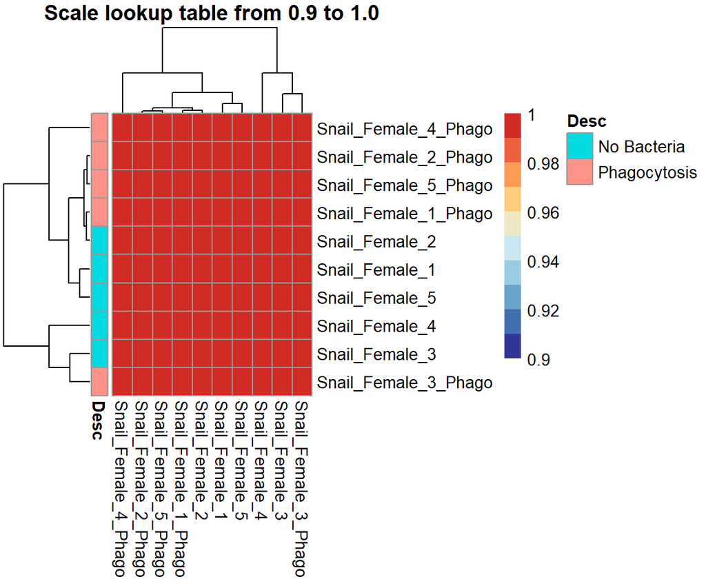

```r
breaksList <- seq(0.9,1, by = 0.01)
#heatmap of correlation
pheatmap(cor(t(meansMat)), annotation_row = rowAnnot,
         color = colorRampPalette(rev(brewer.pal(n = 10, name = "RdYlBu")))(length(breaksList)),
         breaks = breaksList, main = "Scale lookup table from 0.9 to 1.0")
```

make correlation heatmap with default settings for color scale

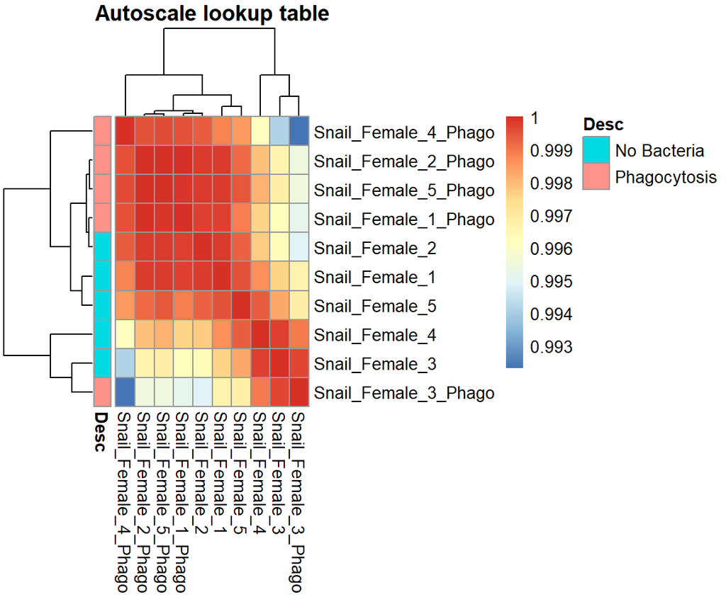

```r
pheatmap(cor(t(meansMat)), main = "Autoscale lookup table", annotation_row = rowAnnot)
```

## Remove outlier samples

Can skip if correlation is high among all or only low between different treatment groups

```r
meansMatBak <- meansMat
#correlation on transposted means matrix
meansCor <- cor(t(meansMat))
#list of samples with mean cor >0.85
tokeep <- findCorrelation(meansCor, cutoff = 0.85, names = FALSE)
tokeep <- sort(tokeep)
#same but return names not index
tokeepnames <- findCorrelation(meansCor, cutoff = 0.85, names = TRUE)
tokeepnames <- sort(tokeepnames)
#subset flowset to remove low cor samples
myflowsetbak <- myflowset
myflowset <- myflowset[c(tokeep)]
#remove dropped samples from annotation data
rowAnnot <- rowAnnot[tokeepnames,]
rowAnnot <- as.data.frame(rowAnnot)
colnames(rowAnnot) <- "Desc"
rownames(rowAnnot) <- myflowset@phenoData@data$name

#sample correlations by feature means, do again without outliers
#get a list of features means, one list item per file
myMeans <- extractMeans(myflowset)
#combine to one big table
myMeans <- rbindlist(myMeans)
#recast to wide form
myMeans <- dcast(myMeans, Sample ~ Feature, value.var = "Means")
#rename rownames
rownames(myMeans) <- myMeans$Sample
#remove redundant col
myMeans[,1] <- NULL
#convert all to numeric
myMeans[] <- lapply(myMeans, function(x) {
  as.numeric(as.character(x))
})

#convert to matrix
meansMat <- as.matrix(myMeans)
rownames(meansMat) <- rownames(myMeans)
rownames(rowAnnot) <- rownames(meansMat)
#check for infinite values#
#meansMat[!is.finite(meansMat)]
#check that sample names match, should return NULL#
#setdiff(myflowset@phenoData@data$names,rownames(rowAnnot))
```

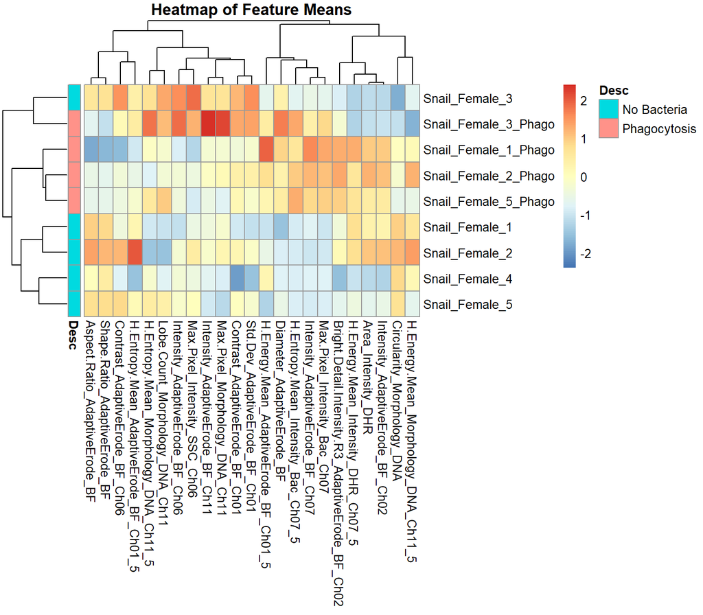

```r
#make clustering heatmap of feature means per sample
pheatmap(meansMat, scale = "column", annotation_row = rowAnnot, main = "Heatmap of Feature Means")
```

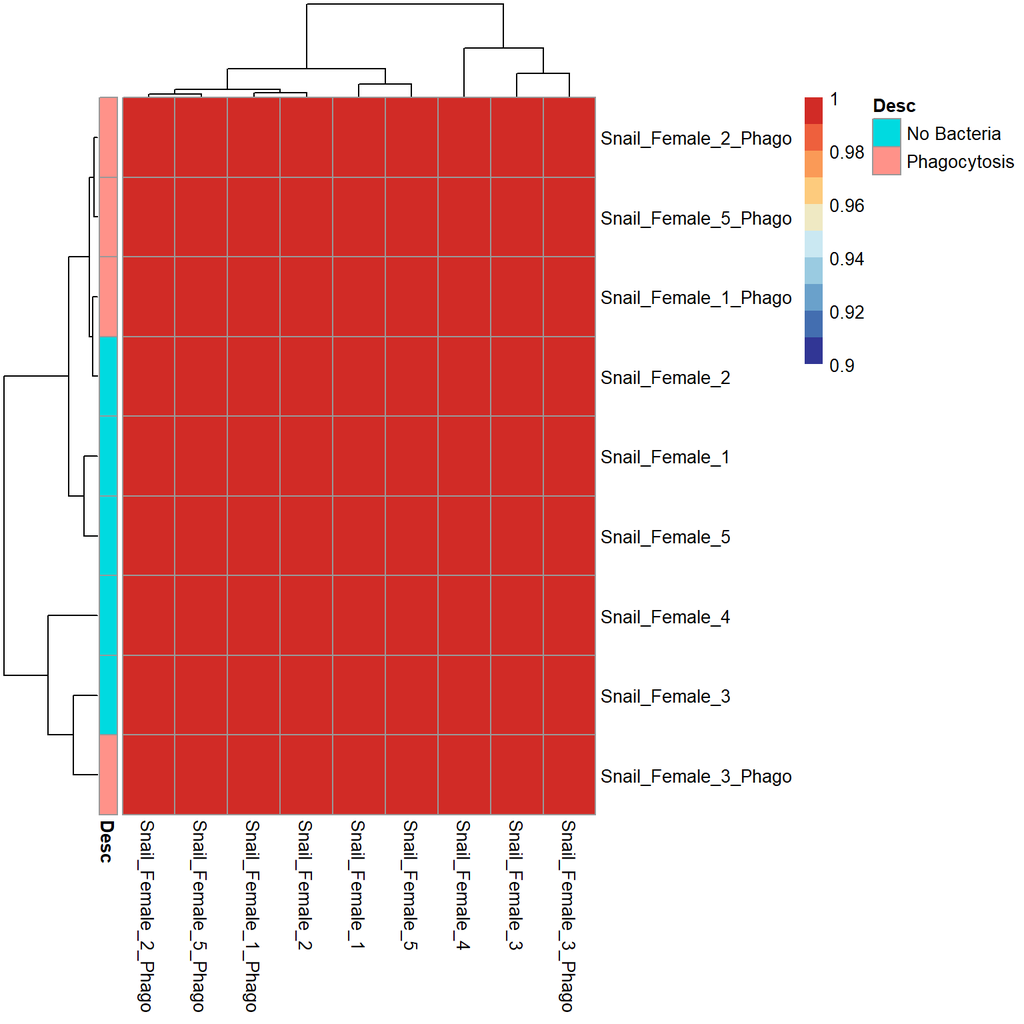

```r
breaksList <- seq(0.9,1, by = 0.01)
#heatmap of correlation
pheatmap(cor(t(meansMat)), annotation_row = rowAnnot,
         color = colorRampPalette(rev(brewer.pal(n = 10, name = "RdYlBu")))(length(breaksList)),
         breaks = breaksList)
```

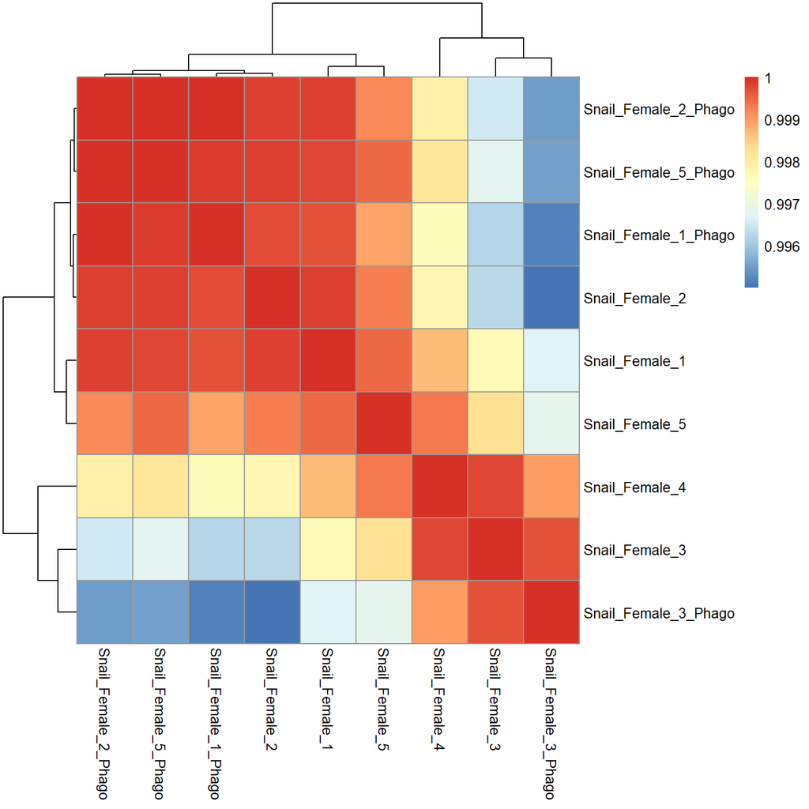

```r
pheatmap(cor(t(meansMat)), method = "spearman")
```

## Transform fluorescent parameters to allow gaussNorm normalization

From “mycolnames” below, identify the index column number of any fluorescence intensity parameters. Make note of these column numbers. On line 319 you’ll put those column numbers into a variable used to specify which data gets logicle transformed.

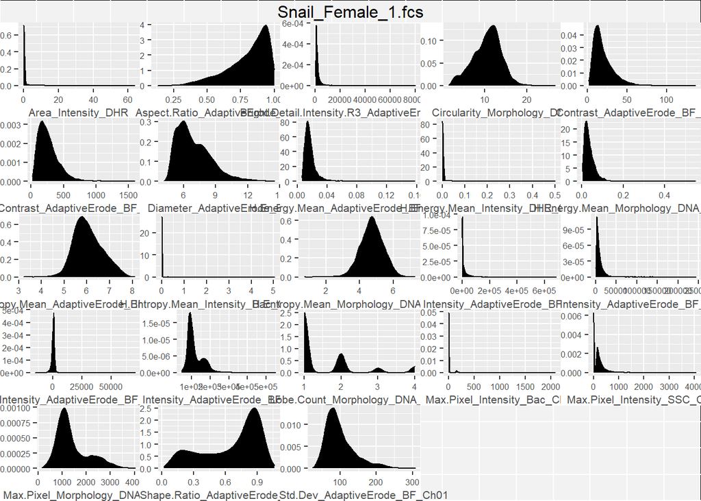

```r
#get new list of parameter names
mycolnames <-  colnames(myflowset[[1]])
#plot all histograms
autoplot(myflowset[[1]])
```

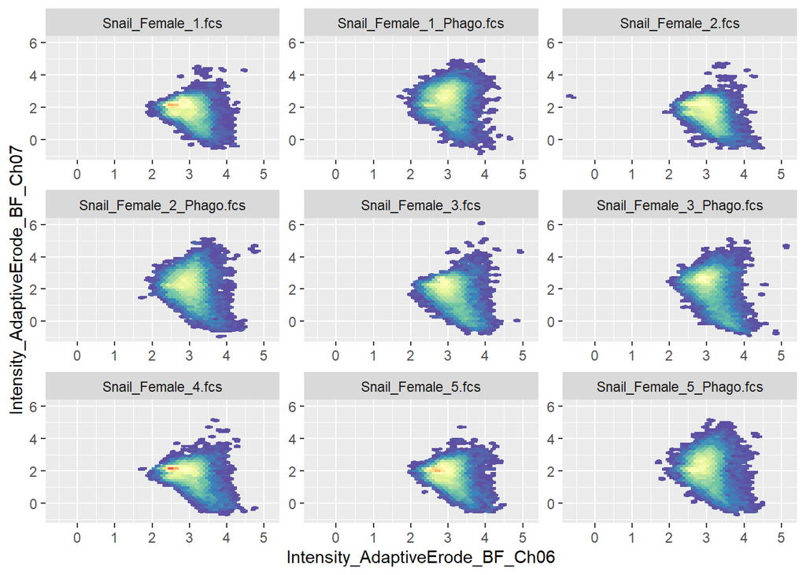

```r
#which parameters to transform, usually want to do all 'intensity' parameters for fluorescence channels
ChnlsToTrans <- mycolnames[c(14:17)]
#estimate logicle transform from data
translist <- estimateLogicle(myflowset[[1]], ChnlsToTrans)
#apply logicle transform to flowset
myflowsetTrans <- transform(myflowset, translist)
#have a look at some data
autoplot(myflowsetTrans, mycolnames[15], mycolnames[16]) + geom_hex(bins=40)
```

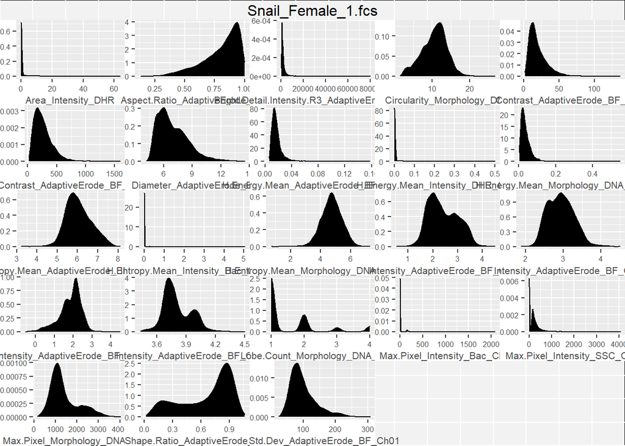

```r
#plot histograms again after transforming data
autoplot(myflowsetTrans[[1]])
```

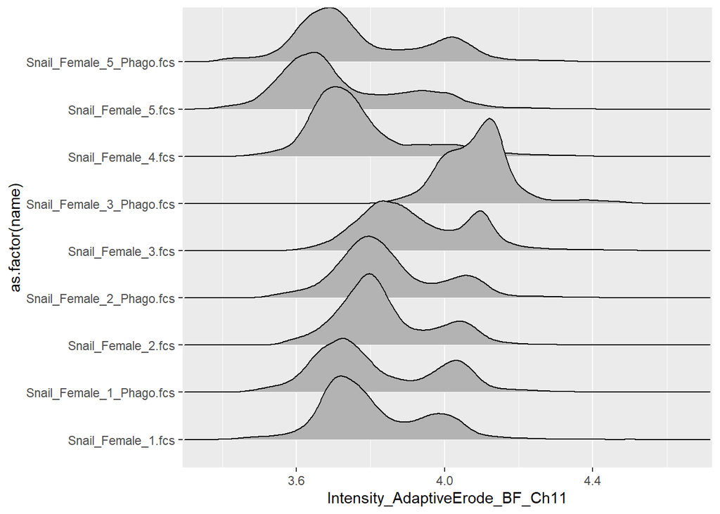

```r
#plot stacked histograms
p <- ggcyto(myflowsetTrans, aes(x = 'Intensity_AdaptiveErode_BF_Ch11'))
p + geom_density_ridges(aes(y = as.factor(name))) + facet_null()
```

## Scale and center flow frames in set for DNA intensity cols

gaussNorm function works better on scaled data.

**For this step you must specify the channel number to use in the code below**

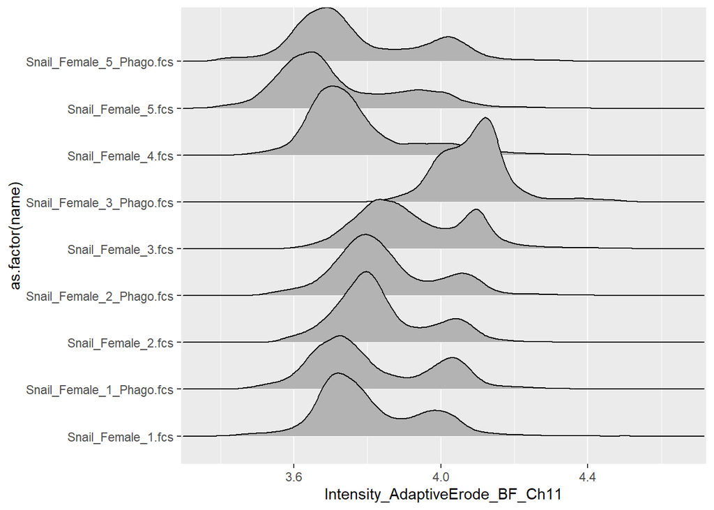

```r
mycolnames <- colnames(myflowset[[1]])

#Check DNA content histograms before scaling data
p <- ggcyto(myflowsetTrans, aes(x = 'Intensity_AdaptiveErode_BF_Ch11'))
p + geom_density_ridges(aes(y = as.factor(name))) + facet_null() #+ xlim(c(-3,3))
```

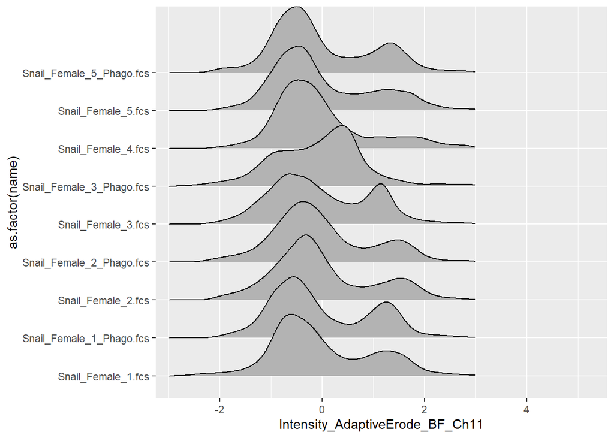

```r
#Make sure scaleDNA function
#pass in transformed flowset and DNA intensity column number
flowsetScaled <- scaleDNA(myflowsetTrans, 17)

#In this case, flowframe 12 has abnormal draq5 staining, uncomment to remove it
# tokeep <- myflowset@phenoData@data$name
# tokeep <- tokeep[c(1:11,13:20)]

#Remove that sample (keep all but index 12 in list of names)
# flowsetScaled <- flowsetScaled[c(tokeep)]

#plot stacked histograms of transformed, original data

# p <- ggcyto(flowsetScaled, aes(x = 'Intensity_AdaptiveErode_BF_Ch02'))
# p + geom_density_ridges(aes(y = as.factor(name))) + facet_null()
#
# p2 <- ggcyto(flowsetScaled, aes(x = 'Intensity_AdaptiveErode_BF_Ch07'))
# p2 + geom_density_ridges(aes(y = as.factor(name))) + facet_null()

p3 <- ggcyto(flowsetScaled, aes(x = 'Intensity_AdaptiveErode_BF_Ch11'))
p3 + geom_density_ridges(aes(y = as.factor(name))) + facet_null() + xlim(c(-3,3))
```